# Visual Improvements

Welcome to the last lesson of our *TacticalSpaceCombat* course. We’re going to make a few minor visual tweaks that will greatly improve the looks of our game.

Godot makes it very easy to boost the appearance of our games with a few clicks.

We’ll also add a shockwave animation to our projectiles, on impact. Writing the shader is outside the scope of this course, but you can see the effect in this video:

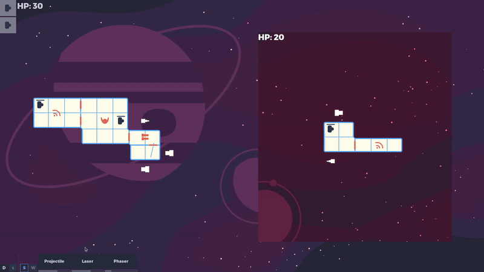

Lasers get a glow effect. This is done entirely with Godot’s built-in tools.

If you want to learn more about these topics, we recommend:

- Shader Secrets to dive deep into 2D and 3D shaders. Learn the math behind them and demystify the GPU pipeline.

[figure not shown]

- VFX Secrets to take your lasers to a whole new level and explore many more VFX possibilities covering many other topics too.

[figure not shown]

## Background image

Our demo feels pretty stale without a background image. Among the assets in the starter project, we provide a background image to cover the entire screen space.

We use the same image for both the player and the AI viewports.

Furthermore, to create the laser glow effect, we’ll need to tweak the

[figure not shown]

`Environment` settings. For that, we’ll need a

[figure not shown]

`WorldEnvironment` node.

All this means that we want these new nodes in the main *TacticalSpaceCombat* scene:

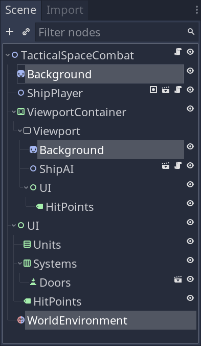

Notice their placement in the tree. We need the *Background* nodes to be drawn under the ships, so they’re higher up in the hierarchy.

Let’s set their properties now. We start with the player *Background* node, the first one from the top:

[figure not shown]

We assign `res://TacticalSpaceCombat/Assets/Background.png` to `Texture`. As mentioned previously, we designed it to fit the entire screen at our chosen resolution.

To place it correctly, all we do is to turn off *Offset -> Centered*.

For the *AI Background* node, I picked these settings, so it feels like a different background:

[figure not shown]

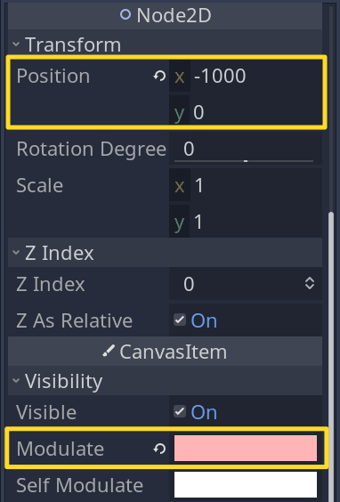

I chose a bright pink color, `#ffb5b5`, for *Modulate* to distinguish the two viewports better.

If you followed these instructions, you should get a similar result to this in your editor viewport:

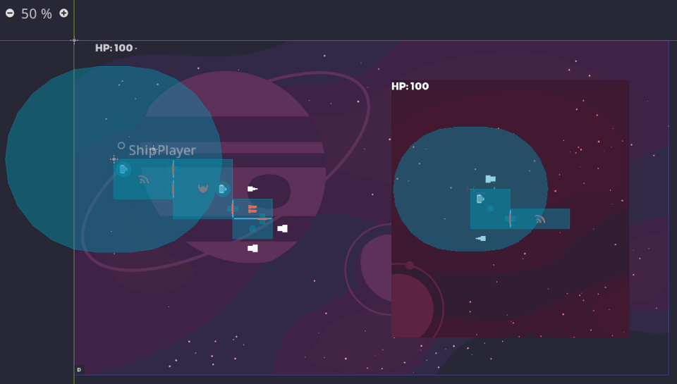

For the

[figure not shown]

`WorldEnvironment` node, create a new

[figure not shown]

`Environment` resource and try these settings:

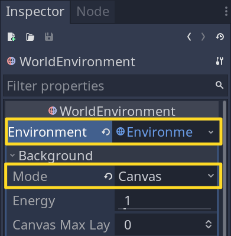

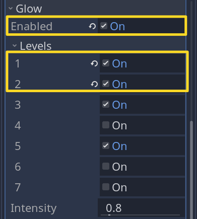

We need *Canvas Mode* to make it work in the 2D viewport.

The other settings are entirely subjective, and you might want to play with them until you find a setup to your liking.

We have finished preparing the groundwork in the main scene file. We can now turn towards the projectile and the laser weapons.

## Projectile shockwave

The shockwave

[figure not shown]

`ShaderMaterial` that we provide has two properties to control the shockwave: *Force* and *Size*.

We’ll have to animate these on impact, so we’ll need an

[figure not shown]

`AnimationPlayer` node.

As for the shockwave shader, it uses the screen space texture, but we’ll still need to attach it to a container. I decided to use a

[figure not shown]

`ColorRect` node for this job which I renamed *Shockwave*.

Open the *Projectile* scene and add the two new nodes:

[figure not shown]

Select the *Shockwave* node and set these properties:

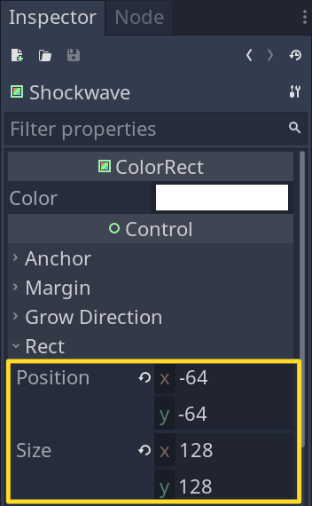

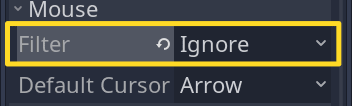

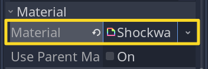

I found that a size of `Vector2(128, 128)` is enough for our needs.

Don’t forget to ignore the mouse by setting *Mouse -> Filter* to *Ignore*.

As for the `Material` property, use the provided asset at `res://TacticalSpaceCombat/Assets/Shockwave.tres`.

We’ll see the shader parameters at work when animating them.

Select the

[figure not shown]

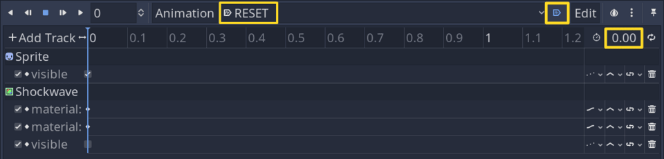

Set the animation to *Autoplay* on *Load* and its timeline length to `0`.

The default track properties are:

[figure not shown]

- `Sprite`:visible: `true`.
- Shockwave:material:`shader_param/`force: `0`.
- Shockwave:material:`shader_param/`size: `0`.
- Shockwave:visible: `false`.

You can find the *Force* and *Size* shader properties under *Material -> Shader Params* when you expand the *Shockwave* resource:

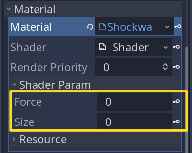

Rename it to `feedback` and change the timeline length to `0.5` seconds:

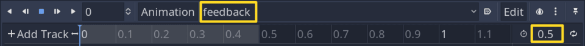

Before moving on to the keyframes, set the *Snap* property to `0.05`. We need a bit more precision than the default:

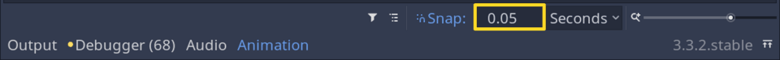

Set these keyframes:

[figure not shown]

- `Sprite`:visible: (`0`, `false`), where the first coordinate, `0`, is the time, and `false` is the value.
- Shockwave:material:`shader_param/`force: (`0`, `0.2`) with *Easing* `2` and (`0.45`, `0`).
- Shockwave:material:`shader_param/`size: (`0`, `0`) with *Easing* `-2` and (`0.5`, `0.5`).
- Shockwave:visiblei: (`0`, `true`)

Additionally, we’ll have a *Functions* track on the *Projectile* node:

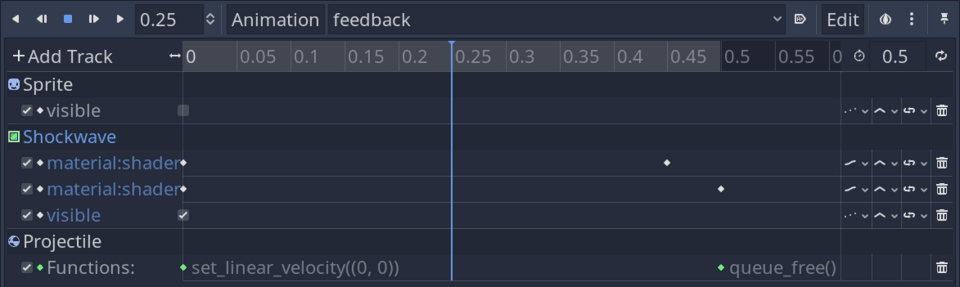

To set the first keyframe on *Projectile*, (`0`, `set_linear_velocity`), `RMB` click the timeline and select *Insert Key*. From the pop-up panel, choose the `set_axis_velocity()` function:

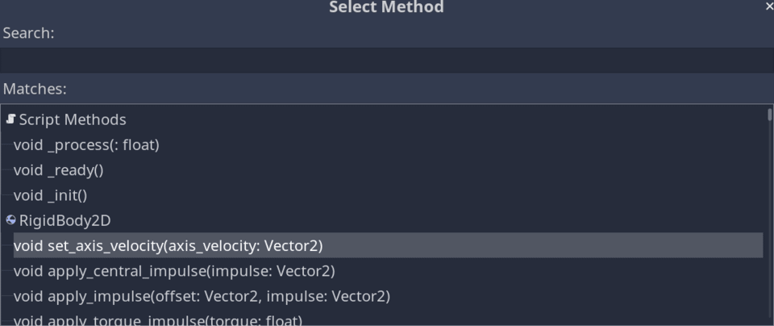

The reason we need to do it this roundabout way is because `set_linear_velocity()` is missing from the list:

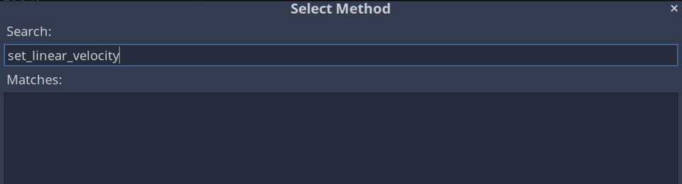

It’s probably a known bug that has to do with it being a setter function for the `linear_velocity` property. But that’s OK. We can tweak the keyframe after picking it.

Speaking of which, select it in the timeline and change the *Name* property to `set_linear_velocity`:

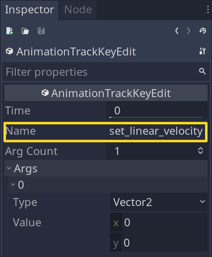

The rest of the values should already be set because `set_axis_velocity()` takes one `Vector2()` argument, just like `set_linear_velocity()`.

`Vector2(0, 0)` is just what we need for the parameter because the idea is to stop the projectile from moving so that the shockwave animation takes place at the impact location.

Finally, the last key is (`0.5`, `queue_free`) to remove the *Projectile* node from the scene when the animation finishes.

Before moving on to the glowing lasers, we have to update a few lines of code.

We want the *Projectile* to play the animation instead of being removed from the scene tree on impact.

### Coding the projectile animation

Open the `Projectile.gd` script. We need to add a reference variable to the new

[figure not shown]

`AnimationPlayer` node:

```
# ...
# var _origin := Vector2.ZERO

onready var animation_player: AnimationPlayer = $AnimationPlayer
```

Next, open `Shield.gd` and replace `body.queue_free()` with `body.animation_player.play("feedback")`:

```
 func _on_body_entered(body: Node) -> void:
    if is_on:
        self.hitpoints -= 1
        timer.start()
-       body.queue_free()
+     body.animation_player.play("feedback")
```

We have to do the same in `ShipTemplate.gd`:

```
 func _on_RoomHitArea2D_body_entered(body: RigidBody2D, room: Room) -> void:
    if not room.position.is_equal_approx(body.params.target_position) or _rng.randf() < _evasion:
        return

-   body.queue_free()
+ body.animation_player.play("feedback")
  _handle_attack(body.params, room)
```

That’s it, we’re done with the projectile shockwave animation. It takes care of removing the node from the scene tree, thanks to the *Functions* track.

Let’s turn our attention to making the lasers glow.

## Glowing lasers

To make the laser lines glow, assign a color to *Modulate* that goes above the regular `[0, 1]` range.

We have to do this change in both *WeaponLaser* and *LaserTracker* scenes.

Let’s start with *WeaponLaser* first. Open the scene and select the

[figure not shown]

`Line2D` node from the scene tree.

Set *Modulate* to a color of (`2`, `2`, `2`). This only works with *Raw* mode turned on:

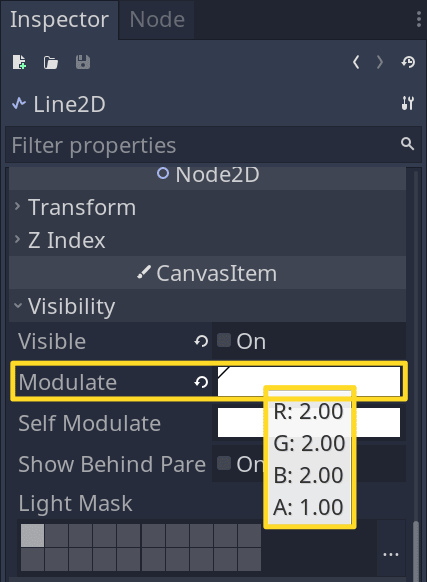

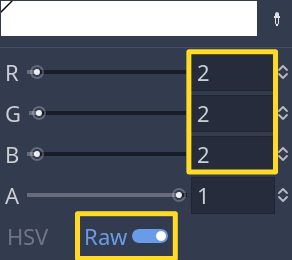

The little triangle indicates that this color goes beyond the regular `[0, 1]` range.

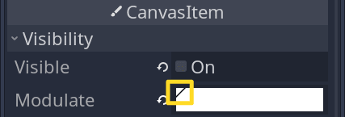

Do the same for the

[figure not shown]

`Line2D` node in the *LaserTracker* scene.

The rest is handled by the *Glow* settings on the

[figure not shown]

`Environment` resource assigned to the

[figure not shown]

`WorldEnvironment` node in the main scene file.

So with this, we finished our last lesson and the *TacticalSpaceCombat* demo course!

Enjoy the new shockwaves and glowing lasers we achieved with minimal effort:

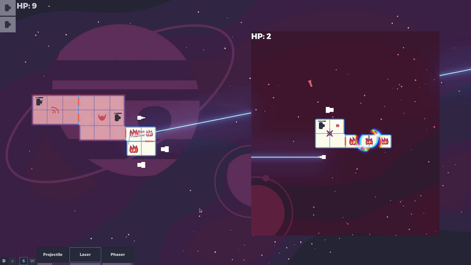

## Conclusion

In this lesson, we finished the course using a

[figure not shown]

`ShaderMaterial` that generates a shockwave when animating its shader parameters.

We saw how to handle a corner case where the *AnimationPlayer Function* track didn’t allow us to pick the desired function from the pop-up menu.

We looked at how to use a

[figure not shown]

`WorldEnvironment` node to make elements glow. We had to assign a color value to the *Modulate* property beyond the usual `[0, 1]` range.

With this, I hope you had a great time following this course and that you learned a few valuable techniques to push your Godot game development workflow!

Kind *Regards* from Răzvan and the GDQuest team!

## Code Reference

`res://TacticalSpaceCombat/Ship/Weapons/Projectile.gd`:

```
class_name Projectile
extends RigidBody2D

const MAX_DISTANCE := 2000

var max_distance := MAX_DISTANCE
var params := {}

var _origin := Vector2.ZERO

onready var animation_player: AnimationPlayer = $AnimationPlayer


func _ready() -> void:
    _origin = position


func _process(delta: float) -> void:
    if position.distance_to(_origin) > max_distance:
        queue_free()
```

`res://TacticalSpaceCombat/Ship/Shield.gd`:

```
tool
extends Area2D

export var powered := true setget set_powered
export var hitpoints_max := 4
export var charge_time := 5
export var radius := 300 setget set_radius
export var height := 100 setget set_height

var hitpoints := 0 setget set_hitpoints
var is_on := false

onready var collision_shape: CollisionShape2D = $CollisionShape2D
onready var polygon: Polygon2D = $Polygon2D
onready var timer: Timer = $Timer


func setup(mean_position: Vector2, mask: int) -> void:
    position = mean_position
    collision_mask = mask


func _ready() -> void:
    self.radius = radius
    self.height = height
    if Engine.editor_hint:
        return

    connect("body_entered", self, "_on_body_entered")
    timer.connect("timeout", self, "_on_Timer_timeout")
    polygon.self_modulate.a = 0
    polygon.polygon = _get_shape_points()
    timer.wait_time = charge_time
    if powered:
        timer.start()


func _on_Timer_timeout() -> void:
    self.hitpoints += 1


func _on_body_entered(body: Node) -> void:
    if is_on:
        self.hitpoints -= 1
        timer.start()
        body.animation_player.play("feedback")


func _get_shape_points() -> PoolVector2Array:
    var out := PoolVector2Array()
    var weight := TAU / 24.0
    var shape: CapsuleShape2D = collision_shape.shape
    for i in range(24):
        var offset := Vector2(0, 0.5 * shape.height * (-1 if i > 6 and i <= 18 else 1))
        out.push_back(shape.radius * Vector2(sin(weight * i), cos(weight * i)) + offset)
        if i == 6 or i == 18:
            out.push_back(shape.radius * Vector2(sin(weight * i), cos(weight * i)) - offset)
    return collision_shape.transform.xform(out)


func set_powered(value: bool) -> void:
    powered = value
    self.hitpoints = 0
    if timer != null:
        timer.call("start" if powered else "stop")


func set_radius(value: int) -> void:
    radius = value
    if collision_shape != null:
        collision_shape.shape.radius = radius


func set_height(value: int) -> void:
    height = value
    if collision_shape != null:
        collision_shape.shape.height = height


func set_hitpoints(value: int) -> void:
    hitpoints = clamp(value, 0, hitpoints_max)
    is_on = hitpoints > 0
    if polygon != null and timer != null:
        polygon.self_modulate.a = hitpoints / float(hitpoints_max)
        timer.call("stop" if hitpoints == hitpoints_max else "start")
```

`res://TacticalSpaceCombat/Ship/ShipTemplate.gd`:

```
tool
extends Node2D

signal hitpoints_changed(hitpoints, is_player)

const LaserTracker := preload("Weapons/LaserTracker.tscn")
const AttackLabel := preload("Weapons/AttackLabel.tscn")
const BreachScene := preload("Hazards/Breach.tscn")
const FireScene := preload("Hazards/Fire.tscn")

export (int, 0, 30) var hitpoints := 30
export (int, 0, 100) var o2_asphyxiation := 10
export (int, 0, 10) var o2_replenish := 2

var has_sensors := false

var _evasion := 0.0
var _slots := {}
var _rng := RandomNumberGenerator.new()

onready var tilemap: TileMap = $TileMap
onready var rooms: Node2D = $Rooms
onready var doors: Node2D = $Doors
onready var units: Node2D = $Units
onready var weapons: Node2D = $Weapons
onready var projectiles: Node2D = $Projectiles
onready var lasers: Node2D = $Lasers
onready var shield: Area2D = $Shield
onready var hazards: Node2D = $Hazards
onready var timer_hazards: Timer = $TimerHazards


func _ready() -> void:
    call("_ready_editor_hint" if Engine.editor_hint else "_ready_not_editor_hint")


func _ready_editor_hint() -> void:
    for room in rooms.get_children():
        room.setup(tilemap)


func _ready_not_editor_hint() -> void:
    timer_hazards.connect("timeout", self, "_on_TimerHazards_timeout")
    _rng.randomize()

    for unit in units.get_children():
        unit.connect("died", self, "_on_Unit_died")
        for door in doors.get_children():
            door.connect("opened", unit, "set_is_walking", [true])

        var position_map := tilemap.world_to_map(unit.path_follow.position)
        _slots[position_map] = unit

    for room in rooms.get_children():
        room.connect("modifier_changed", self, "_on_Room_modifier_changed")
        room.connect("fog_changed", self, "_on_Room_fog_changed")
        room.connect("area_entered", self, "_on_RoomArea2D_area_entered", [room])
        room.hit_area.connect("body_entered", self, "_on_RoomHitArea2D_body_entered", [room])
        room.setup(tilemap)

        for point in room:
            tilemap.set_cellv(point, 0)

        if is_in_group("player") and room.type == Room.Type.SENSORS:
            has_sensors = true

    tilemap.setup(rooms, doors)
    projectiles.setup(rooms.mean_position)
    shield.setup(
        rooms.mean_position,
        Global.Layers.SHIPPLAYER if is_in_group("player") else Global.Layers.SHIPAI
    )


func _get_configuration_warning() -> String:
    var is_verified := (
        is_in_group("player")
        and weapons.get_child_count() <= 4
        or not is_in_group("player")
    )
    return "" if is_verified else "%s can't have more than 4 weapons!" % name


func _unhandled_input(event: InputEvent) -> void:
    if not event.is_action_pressed("right_click"):
        return

    for unit in get_tree().get_nodes_in_group("selected-unit"):
        var point1: Vector2 = tilemap.world_to_map(unit.path_follow.position)
        for room in get_tree().get_nodes_in_group("selected-room"):
            if not room.owner.is_in_group("player"):
                break

            var point2: Vector2 = room.get_slot(_slots, unit)
            if is_inf(point2.x):
                break

            var path: Curve2D = tilemap.find_path(point1, point2)
            Utils.erase_value(_slots, unit)
            _slots[point2] = unit
            unit.walk(path)


func _on_UIDoorsButton_pressed() -> void:
    var has_opened_doors := false
    for door in doors.get_children():
        if door.is_open:
            has_opened_doors = true
            break

    for door in doors.get_children():
        door.is_open = not has_opened_doors


func _on_RoomHitArea2D_body_entered(body: RigidBody2D, room: Room) -> void:
    if not room.position.is_equal_approx(body.params.target_position) or _rng.randf() < _evasion:
        return

    body.animation_player.play("feedback")
    _handle_attack(body.params, room)


func _on_RoomArea2D_area_entered(area: Area2D, room: Room) -> void:
    if area.is_in_group("laser"):
        _handle_attack(area.params, room)


func _on_Room_modifier_changed(type: int, value: float) -> void:
    match type:
        Room.Type.HELM:
            _evasion = value
        Room.Type.WEAPONS:
            for controller in weapons.get_children():
                controller.weapon.modifier = value


func _on_Room_fog_changed(room: Room, has_fog: bool) -> void:
    for hazard in hazards.get_children():
        if room.has_point(tilemap.world_to_map(hazard.position)):
            hazard.visible = not has_fog


func _on_Unit_died(unit: Unit) -> void:
    Utils.erase_value(_slots, unit)
    for room in rooms.get_children():
        room.units.erase(unit)


func _on_Fire_spread(fire_position: Vector2) -> void:
    var neighbor_position := _get_neighbor_position(fire_position)
    var fire: Fire = hazards.add(FireScene, neighbor_position)
    if fire != null:
        fire.connect("attacked", self, "_take_damage")
        fire.connect("spread", self, "_on_Fire_spread")
        for room in rooms.get_children():
            if room.has_point(tilemap.world_to_map(fire.position)):
                fire.visible = not _has_fog(room)
                break


func _on_TimerHazards_timeout() -> void:
    _hazards_breach()
    _hazards_units()
    _hazards_o2()


func _hazards_breach() -> void:
    for hazard in hazards.get_children():
        if hazard is Fire:
            continue

        for room in rooms.get_children():
            if room.has_point(tilemap.world_to_map(hazard.position)):
                room.o2 -= hazard.attack


func _hazards_units() -> void:
    for room in rooms.get_children():
        var hazard_was_attacked := false
        for hazard in hazards.get_children():
            if room.has_point(tilemap.world_to_map(hazard.position)):
                for unit in room.units:
                    if hazard is Fire:
                        unit.take_damage(hazard.attack)

                    if not hazard_was_attacked:
                        hazard.take_damage(unit.attack)
                        hazard_was_attacked = true

                if hazard is Fire and room.o2 < o2_asphyxiation:
                    hazard.take_damage(hazard.o2_damage)

        for unit in room.units:
            if room.o2 < o2_asphyxiation:
                unit.take_damage(unit.o2_damage)


func _hazards_o2() -> void:
    var o2_associations := {}
    var room_associations := {}
    for door in doors.get_children():
        if not door.is_open:
            continue

        var o2_mean := 0.0
        for room in door.rooms:
            o2_mean += room.o2
            room_associations[room] = room_associations.get(room, 0) + 1
        o2_mean /= door.rooms.size()

        for room in door.rooms:
            o2_associations[room] = o2_associations.get(room, 0) + o2_mean

    for room in rooms.get_children():
        if room in o2_associations:
            o2_associations[room] /= room_associations[room]
            room.o2 = lerp(room.o2, o2_associations[room], 0.5)
        room.o2 += o2_replenish


func add_laser_tracker(color: Color) -> Node:
    var laser_tracker := LaserTracker.instance()
    lasers.add_child(laser_tracker)
    laser_tracker.setup(color, rooms, shield)
    return laser_tracker


func _has_fog(room: Room) -> bool:
    var room_has_fog := not has_sensors
    if is_in_group("player"):
        room_has_fog = room_has_fog and room.units.empty()
    return room_has_fog


func _handle_attack(params: Dictionary, room: Room) -> void:
    var room_has_fog := _has_fog(room)

    if _rng.randf() < params.chance_fire:
        var fire: Fire = hazards.add(FireScene, room.randvi())
        if fire != null:
            fire.connect("attacked", self, "_take_damage")
            fire.connect("spread", self, "_on_Fire_spread")
            fire.visible = not room_has_fog

    if _rng.randf() < params.chance_breach:
        var breach: Breach = hazards.add(BreachScene, room.randvi())
        if breach != null:
            breach.visible = not room_has_fog

    _take_damage(params.attack, room.position)


func _take_damage(attack: int, object_position: Vector2) -> void:
    var attack_label := AttackLabel.instance()
    attack_label.setup(attack, object_position)
    add_child(attack_label)

    hitpoints -= attack
    hitpoints = max(0, hitpoints)
    emit_signal("hitpoints_changed", hitpoints, is_in_group("player"))


func _get_neighbor_position(at: Vector2) -> Vector2:
    var neighbors := []
    var point1 := tilemap.world_to_map(at)
    for offset in Utils.DIRECTIONS:
        var point2: Vector2 = point1 + offset
        if tilemap.get_cellv(point2) != tilemap.INVALID_CELL:
            neighbors.push_back(tilemap.map_to_world(point2) + 0.5 * tilemap.cell_size)
    var index := _rng.randi_range(0, neighbors.size() - 1)
    return neighbors[index]
```